# Week2 Project

## R Markdown

Thank you for reviewing my JHU Week 2 file. The first assigment is: Code for reading in the dataset and/or processing the data Let’s start with setting the working directory and loading the necessary packages. Then lets read and clean the data up a bit

```r
setwd('C:/Users/Timon/Documents/School 2019-2020/Coding/data interpretation')
library(tidyverse)
df <- read.csv('activity.csv', stringsAsFactors = FALSE)
df$steps <- as.numeric(df$steps)
df$date <- as.POSIXct(strptime(df$date, '%Y-%m-%d'))
```

2. Histogram of the total number of steps taken each day For this part, we first need to create a new dataframe which contains necessary data

```r
dailysteps <- df %>%
        na.omit() %>%
        group_by(date) %>%
        summarise_at(vars(steps),
        list(Daily_Steps = sum))
```

Now we can easily plot this using the ggplot2 package

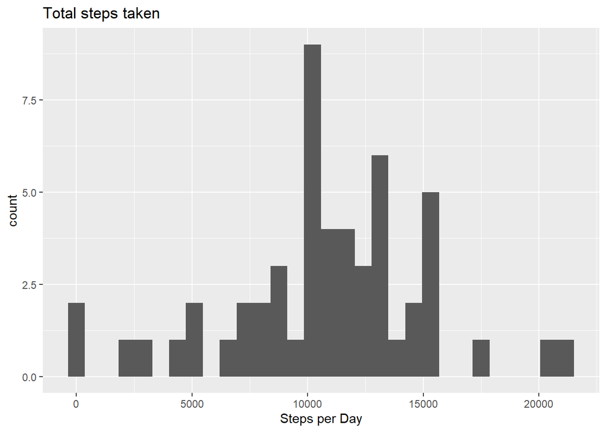

```r
ggplot(data = dailysteps, aes(dailysteps$Daily_Steps)) +
      geom_histogram() +
      labs(title = 'Total steps taken') +
      labs(x = 'Steps per Day')
```

3. This corresponds to a mean of 1.076618910^{4} and a median of 1.076510^{4}. These numbers were retrieved using inline computations.
4. Time series plot of the average number of steps taken Next lets make a plot of the average amount of steps taken per 5 minute interval. First we have to make the correct dataset(similarly to 2.), then we plot is.

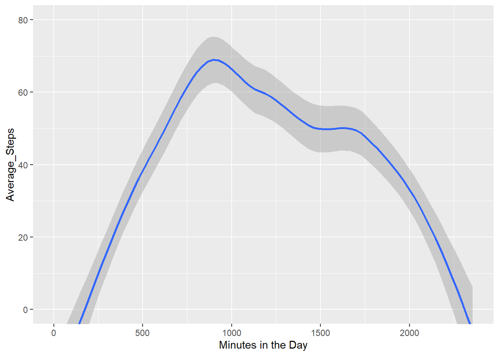

```r
averagesteps <- df %>%
    na.omit() %>%
    group_by(interval) %>%
    summarise_at(vars(steps),
    list(Average_Steps = mean))

ggplot(data = averagesteps, aes(x = interval, y = Average_Steps)) +
      geom_smooth() +
      labs(x = 'Minutes in the Day') +
      coord_cartesian(ylim=c(0,80))
```

5. The maximum amount of average steps taken within an interval is 206.1698113
6. First we take a look at how much missing data there is

```r
nrow(df[!complete.cases(df), ])/nrow(df)*100
```

```
## [1] 13.11475
```

```r
sum(is.na(df))
```

```
## [1] 2304
```

```r
table(df[,2])
```

```
##
## 2012-10-01 2012-10-02 2012-10-03 2012-10-04 2012-10-05 2012-10-06
##        288        288        288        288        288        288
## 2012-10-07 2012-10-08 2012-10-09 2012-10-10 2012-10-11 2012-10-12
##        288        288        288        288        288        288
## 2012-10-13 2012-10-14 2012-10-15 2012-10-16 2012-10-17 2012-10-18
##        288        288        288        288        288        288
## 2012-10-19 2012-10-20 2012-10-21 2012-10-22 2012-10-23 2012-10-24
##        288        288        288        288        288        288
## 2012-10-25 2012-10-26 2012-10-27 2012-10-28 2012-10-29 2012-10-30
##        288        288        288        288        288        288
## 2012-10-31 2012-11-01 2012-11-02 2012-11-03 2012-11-04 2012-11-05
##        288        288        288        288        288        288
## 2012-11-06 2012-11-07 2012-11-08 2012-11-09 2012-11-10 2012-11-11
##        288        288        288        288        288        288
## 2012-11-12 2012-11-13 2012-11-14 2012-11-15 2012-11-16 2012-11-17
##        288        288        288        288        288        288
## 2012-11-18 2012-11-19 2012-11-20 2012-11-21 2012-11-22 2012-11-23
##        288        288        288        288        288        288
## 2012-11-24 2012-11-25 2012-11-26 2012-11-27 2012-11-28 2012-11-29
##        288        288        288        288        288        288
## 2012-11-30
##        288
```

13% is missing, which corresponds with 2304 NAs. Using table(df[,2]) we can see that every day has 288 measurements.

What does this table look like if we remove all missing data?

```r
cleandf <- na.omit(df)
table(cleandf[,2])
```

```
##
## 2012-10-02 2012-10-03 2012-10-04 2012-10-05 2012-10-06 2012-10-07
##        288        288        288        288        288        288
## 2012-10-09 2012-10-10 2012-10-11 2012-10-12 2012-10-13 2012-10-14
##        288        288        288        288        288        288
## 2012-10-15 2012-10-16 2012-10-17 2012-10-18 2012-10-19 2012-10-20
##        288        288        288        288        288        288
## 2012-10-21 2012-10-22 2012-10-23 2012-10-24 2012-10-25 2012-10-26
##        288        288        288        288        288        288
## 2012-10-27 2012-10-28 2012-10-29 2012-10-30 2012-10-31 2012-11-02
##        288        288        288        288        288        288
## 2012-11-03 2012-11-05 2012-11-06 2012-11-07 2012-11-08 2012-11-11
##        288        288        288        288        288        288
## 2012-11-12 2012-11-13 2012-11-15 2012-11-16 2012-11-17 2012-11-18
##        288        288        288        288        288        288
## 2012-11-19 2012-11-20 2012-11-21 2012-11-22 2012-11-23 2012-11-24
##        288        288        288        288        288        288
## 2012-11-25 2012-11-26 2012-11-27 2012-11-28 2012-11-29
##        288        288        288        288        288
```

You now see that 8 days are missing(like the first), which makes sense, since 8*288=2304. Imputing data means that we need to add these days. From what I can see, there does not seem to be an obvious pattern to which days are missing from the data. Entire weeks can go by without missing data, and then data is absent two days in a row. Since the missing days are random, the best way to impute this data is to copy the average steps per interval, and paste them to the missing dates Luckily we already made a dataset for the average steps, so all we have to do is combine this data

```r
impute_df <- df
for(i in seq_len(nrow(impute_df))){
  if(is.na(impute_df$steps[i]) == TRUE){
  impute_df$steps[i] <- averagesteps$Average_Steps[averagesteps$interval == impute_df$interval[i]]
  }
}
table(impute_df[,2])
```

```
##
## 2012-10-01 2012-10-02 2012-10-03 2012-10-04 2012-10-05 2012-10-06
##        288        288        288        288        288        288
## 2012-10-07 2012-10-08 2012-10-09 2012-10-10 2012-10-11 2012-10-12
##        288        288        288        288        288        288
## 2012-10-13 2012-10-14 2012-10-15 2012-10-16 2012-10-17 2012-10-18
##        288        288        288        288        288        288
## 2012-10-19 2012-10-20 2012-10-21 2012-10-22 2012-10-23 2012-10-24
##        288        288        288        288        288        288
## 2012-10-25 2012-10-26 2012-10-27 2012-10-28 2012-10-29 2012-10-30
##        288        288        288        288        288        288
## 2012-10-31 2012-11-01 2012-11-02 2012-11-03 2012-11-04 2012-11-05
##        288        288        288        288        288        288
## 2012-11-06 2012-11-07 2012-11-08 2012-11-09 2012-11-10 2012-11-11
##        288        288        288        288        288        288
## 2012-11-12 2012-11-13 2012-11-14 2012-11-15 2012-11-16 2012-11-17
##        288        288        288        288        288        288
## 2012-11-18 2012-11-19 2012-11-20 2012-11-21 2012-11-22 2012-11-23
##        288        288        288        288        288        288
## 2012-11-24 2012-11-25 2012-11-26 2012-11-27 2012-11-28 2012-11-29
##        288        288        288        288        288        288
## 2012-11-30
##        288
```

As you can see, all missing days are now complete.

7. Now lets repeat the graph with the new df

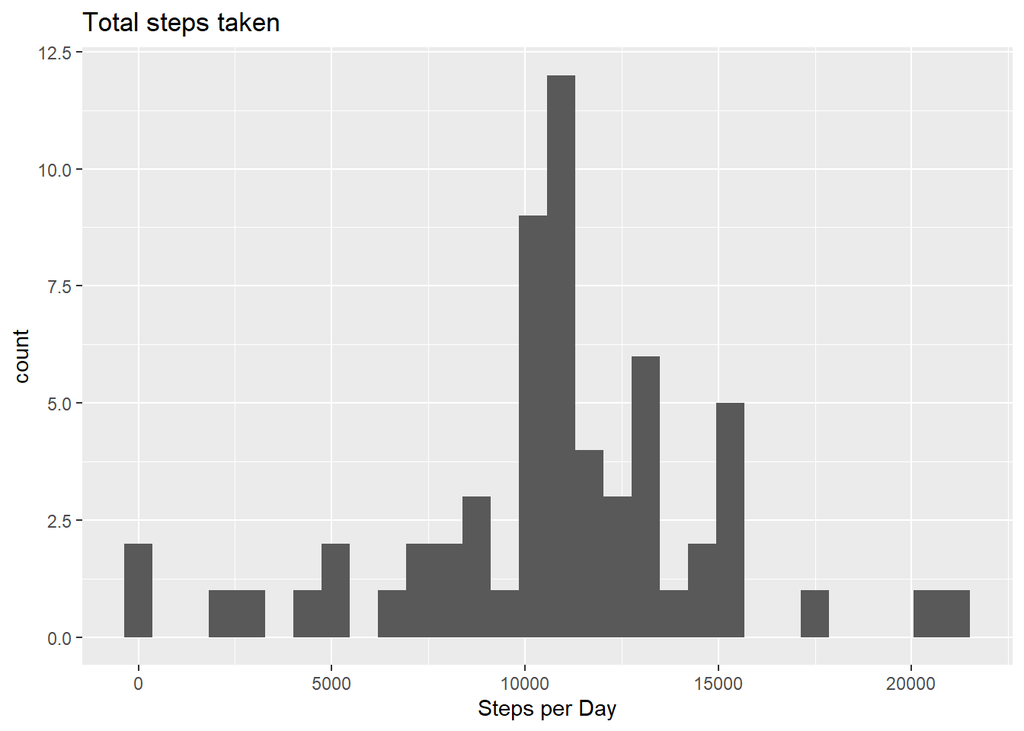

```r
imputedsteps <- impute_df %>%
  group_by(date) %>%
  summarise_at(vars(steps),
  list(Daily_Steps = sum))

ggplot(data = imputedsteps, aes(imputedsteps$Daily_Steps)) +
  geom_histogram() +
  labs(title = 'Total steps taken') +
  labs(x = 'Steps per Day')
```

Now to compare, the mean of the imputed data is 1.076618910^{4} and the median is 1.076618910^{4}, which is very similar to data before imputing the NAs.

8. finally, we need to compare weekdays and weekends. In order to do this, lets take a look in the calender to see which days were weekends, and then create two datasets NOTE: the course recommends using the weekdays( function, I only saw this after preparing to hand in my document, which is why it is not used here)

```r
df$date <- as.POSIXct(strptime(df$date, '%Y-%m-%d'))
weeksteps <- df %>%
              na.omit() %>%
              subset(!(date == '2012-10-06' | date == '2012-10-07'
                      | date == '2012-10-13' | date == '2012-10-14'
                      | date == '2012-10-20' | date == '2012-10-21'
                      | date == '2012-10-27' | date == '2012-10-28'
                      | date == '2012-11-03' | date == '2012-11-04'
                      | date == '2012-11-10' | date == '2012-11-11'
                      | date == '2012-11-17' | date == '2012-11-18'
                      | date == '2012-11-24' | date == '2012-11-25'))
averageweek <- weeksteps %>%
  na.omit() %>%
  group_by(interval) %>%
        summarise_at(vars(steps),
        list(Average_Steps = mean))
```

This is repeated for the weekend. Finally, we will plot both of these in a single graph.

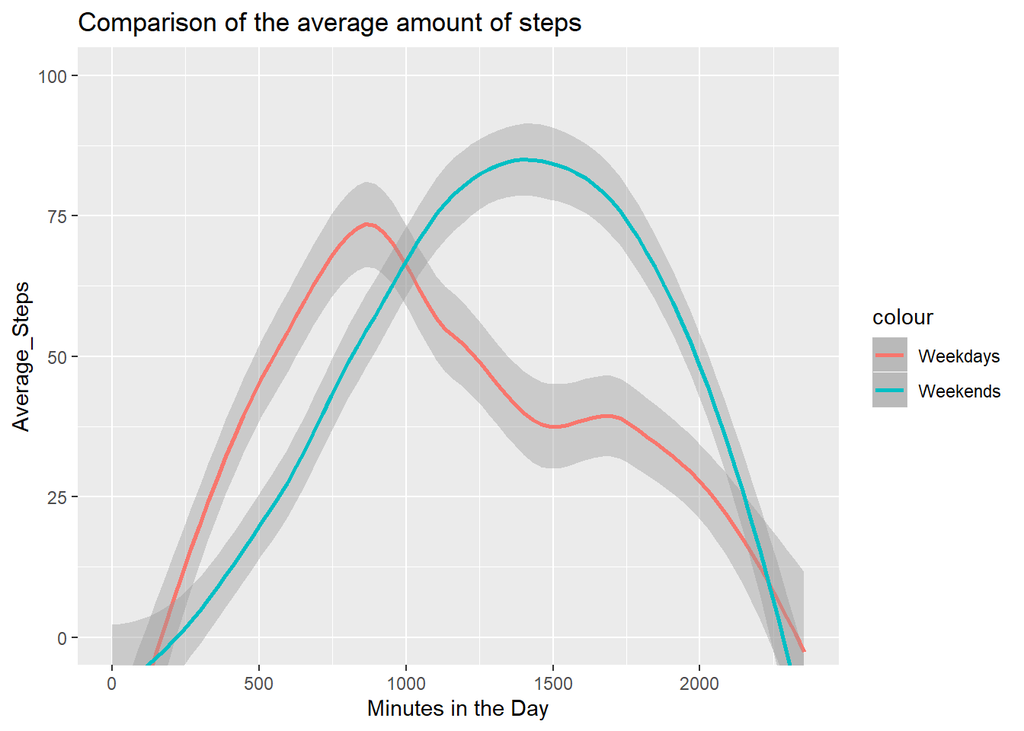

```r
ggplot(data = averageweek, aes(x = interval, y = Average_Steps)) +
  geom_smooth(aes(color = 'Weekdays')) +
  geom_smooth(data = averageweekend, aes(color = 'Weekends')) +
  labs(x = 'Minutes in the Day', title = 'Comparison of the average amount of steps') +
  coord_cartesian(ylim=c(0,100))
```